# Risk Factor Analysis

## Outcome Variable

**Outcome Variable:** stunted

## Predictor Variables

**Intervention Variable:** mhtcm

**Adjustment Set:**

unadjusted

## Stratifying Variables

The analysis was stratified on these variable(s):

- agecat
- studyid
- country

## Data Summary

| agecat | studyid | country | A | n | nA | nAY0 | nAY1 |
| --- | --- | --- | --- | --- | --- | --- | --- |
| Birth | ki0047075b-MAL-ED | BANGLADESH | >=160 | 246 | 4 | 4 | 0 |
| Birth | ki0047075b-MAL-ED | BANGLADESH | <145 | 246 | 55 | 41 | 14 |
| Birth | ki0047075b-MAL-ED | BANGLADESH | [145-150) | 246 | 86 | 70 | 16 |
| Birth | ki0047075b-MAL-ED | BANGLADESH | [150-155) | 246 | 80 | 71 | 9 |
| Birth | ki0047075b-MAL-ED | BANGLADESH | [155-160) | 246 | 21 | 18 | 3 |
| Birth | ki0047075b-MAL-ED | BRAZIL | >=160 | 184 | 57 | 54 | 3 |
| Birth | ki0047075b-MAL-ED | BRAZIL | <145 | 184 | 7 | 6 | 1 |
| Birth | ki0047075b-MAL-ED | BRAZIL | [145-150) | 184 | 30 | 24 | 6 |
| Birth | ki0047075b-MAL-ED | BRAZIL | [150-155) | 184 | 40 | 36 | 4 |
| Birth | ki0047075b-MAL-ED | BRAZIL | [155-160) | 184 | 50 | 45 | 5 |
| Birth | ki0047075b-MAL-ED | INDIA | >=160 | 198 | 13 | 12 | 1 |
| Birth | ki0047075b-MAL-ED | INDIA | <145 | 198 | 24 | 20 | 4 |
| Birth | ki0047075b-MAL-ED | INDIA | [145-150) | 198 | 57 | 44 | 13 |
| Birth | ki0047075b-MAL-ED | INDIA | [150-155) | 198 | 71 | 59 | 12 |
| Birth | ki0047075b-MAL-ED | INDIA | [155-160) | 198 | 33 | 31 | 2 |
| Birth | ki0047075b-MAL-ED | NEPAL | >=160 | 172 | 2 | 2 | 0 |
| Birth | ki0047075b-MAL-ED | NEPAL | <145 | 172 | 25 | 22 | 3 |
| Birth | ki0047075b-MAL-ED | NEPAL | [145-150) | 172 | 64 | 59 | 5 |
| Birth | ki0047075b-MAL-ED | NEPAL | [150-155) | 172 | 56 | 48 | 8 |
| Birth | ki0047075b-MAL-ED | NEPAL | [155-160) | 172 | 25 | 23 | 2 |
| Birth | ki0047075b-MAL-ED | PERU | >=160 | 276 | 11 | 10 | 1 |
| Birth | ki0047075b-MAL-ED | PERU | <145 | 276 | 40 | 29 | 11 |
| Birth | ki0047075b-MAL-ED | PERU | [145-150) | 276 | 102 | 89 | 13 |
| Birth | ki0047075b-MAL-ED | PERU | [150-155) | 276 | 76 | 71 | 5 |
| Birth | ki0047075b-MAL-ED | PERU | [155-160) | 276 | 47 | 44 | 3 |
| Birth | ki0047075b-MAL-ED | SOUTH AFRICA | >=160 | 228 | 104 | 93 | 11 |
| Birth | ki0047075b-MAL-ED | SOUTH AFRICA | <145 | 228 | 8 | 8 | 0 |
| Birth | ki0047075b-MAL-ED | SOUTH AFRICA | [145-150) | 228 | 11 | 9 | 2 |
| Birth | ki0047075b-MAL-ED | SOUTH AFRICA | [150-155) | 228 | 36 | 32 | 4 |
| Birth | ki0047075b-MAL-ED | SOUTH AFRICA | [155-160) | 228 | 69 | 63 | 6 |

[output cut: 585 more lines]

The following strata were considered:

- agecat: 12 months, studyid: ki0047075b-MAL-ED, country: BANGLADESH
- agecat: 12 months, studyid: ki0047075b-MAL-ED, country: BRAZIL
- agecat: 12 months, studyid: ki0047075b-MAL-ED, country: INDIA
- agecat: 12 months, studyid: ki0047075b-MAL-ED, country: NEPAL
- agecat: 12 months, studyid: ki0047075b-MAL-ED, country: PERU
- agecat: 12 months, studyid: ki0047075b-MAL-ED, country: SOUTH AFRICA
- agecat: 12 months, studyid: ki0047075b-MAL-ED, country: TANZANIA, UNITED REPUBLIC OF
- agecat: 12 months, studyid: ki1000304b-SAS-FoodSuppl, country: INDIA
- agecat: 12 months, studyid: ki1017093-NIH-Birth, country: BANGLADESH
- agecat: 12 months, studyid: ki1017093b-PROVIDE, country: BANGLADESH
- agecat: 12 months, studyid: ki1017093c-NIH-Crypto, country: BANGLADESH
- agecat: 12 months, studyid: ki1066203-TanzaniaChild2, country: TANZANIA, UNITED REPUBLIC OF
- agecat: 12 months, studyid: ki1101329-Keneba, country: GAMBIA
- agecat: 12 months, studyid: ki1112895-Guatemala BSC, country: GUATEMALA
- agecat: 12 months, studyid: ki1126311-ZVITAMBO, country: ZIMBABWE
- agecat: 12 months, studyid: ki1135781-COHORTS, country: GUATEMALA
- agecat: 12 months, studyid: ki1135781-COHORTS, country: INDIA
- agecat: 12 months, studyid: ki1135781-COHORTS, country: PHILIPPINES
- agecat: 12 months, studyid: ki1148112-LCNI-5, country: MALAWI
- agecat: 18 months, studyid: ki0047075b-MAL-ED, country: BANGLADESH
- agecat: 18 months, studyid: ki0047075b-MAL-ED, country: BRAZIL
- agecat: 18 months, studyid: ki0047075b-MAL-ED, country: INDIA
- agecat: 18 months, studyid: ki0047075b-MAL-ED, country: NEPAL
- agecat: 18 months, studyid: ki0047075b-MAL-ED, country: PERU
- agecat: 18 months, studyid: ki0047075b-MAL-ED, country: SOUTH AFRICA
- agecat: 18 months, studyid: ki0047075b-MAL-ED, country: TANZANIA, UNITED REPUBLIC OF
- agecat: 18 months, studyid: ki1000304b-SAS-FoodSuppl, country: INDIA
- agecat: 18 months, studyid: ki1017093-NIH-Birth, country: BANGLADESH
- agecat: 18 months, studyid: ki1017093b-PROVIDE, country: BANGLADESH
- agecat: 18 months, studyid: ki1017093c-NIH-Crypto, country: BANGLADESH
- agecat: 18 months, studyid: ki1066203-TanzaniaChild2, country: TANZANIA, UNITED REPUBLIC OF
- agecat: 18 months, studyid: ki1101329-Keneba, country: GAMBIA
- agecat: 18 months, studyid: ki1126311-ZVITAMBO, country: ZIMBABWE
- agecat: 18 months, studyid: ki1135781-COHORTS, country: GUATEMALA
- agecat: 18 months, studyid: ki1135781-COHORTS, country: PHILIPPINES
- agecat: 18 months, studyid: ki1148112-LCNI-5, country: MALAWI
- agecat: 24 months, studyid: ki0047075b-MAL-ED, country: BANGLADESH
- agecat: 24 months, studyid: ki0047075b-MAL-ED, country: BRAZIL
- agecat: 24 months, studyid: ki0047075b-MAL-ED, country: INDIA
- agecat: 24 months, studyid: ki0047075b-MAL-ED, country: NEPAL
- agecat: 24 months, studyid: ki0047075b-MAL-ED, country: PERU
- agecat: 24 months, studyid: ki0047075b-MAL-ED, country: SOUTH AFRICA
- agecat: 24 months, studyid: ki0047075b-MAL-ED, country: TANZANIA, UNITED REPUBLIC OF
- agecat: 24 months, studyid: ki1017093-NIH-Birth, country: BANGLADESH
- agecat: 24 months, studyid: ki1017093b-PROVIDE, country: BANGLADESH
- agecat: 24 months, studyid: ki1017093c-NIH-Crypto, country: BANGLADESH
- agecat: 24 months, studyid: ki1066203-TanzaniaChild2, country: TANZANIA, UNITED REPUBLIC OF
- agecat: 24 months, studyid: ki1101329-Keneba, country: GAMBIA
- agecat: 24 months, studyid: ki1126311-ZVITAMBO, country: ZIMBABWE
- agecat: 24 months, studyid: ki1135781-COHORTS, country: GUATEMALA
- agecat: 24 months, studyid: ki1135781-COHORTS, country: INDIA
- agecat: 24 months, studyid: ki1135781-COHORTS, country: PHILIPPINES
- agecat: 24 months, studyid: ki1148112-LCNI-5, country: MALAWI
- agecat: 3 months, studyid: ki0047075b-MAL-ED, country: BANGLADESH
- agecat: 3 months, studyid: ki0047075b-MAL-ED, country: BRAZIL
- agecat: 3 months, studyid: ki0047075b-MAL-ED, country: INDIA
- agecat: 3 months, studyid: ki0047075b-MAL-ED, country: NEPAL
- agecat: 3 months, studyid: ki0047075b-MAL-ED, country: PERU
- agecat: 3 months, studyid: ki0047075b-MAL-ED, country: SOUTH AFRICA
- agecat: 3 months, studyid: ki0047075b-MAL-ED, country: TANZANIA, UNITED REPUBLIC OF
- agecat: 3 months, studyid: ki1000304b-SAS-FoodSuppl, country: INDIA
- agecat: 3 months, studyid: ki1017093-NIH-Birth, country: BANGLADESH
- agecat: 3 months, studyid: ki1017093b-PROVIDE, country: BANGLADESH
- agecat: 3 months, studyid: ki1017093c-NIH-Crypto, country: BANGLADESH
- agecat: 3 months, studyid: ki1066203-TanzaniaChild2, country: TANZANIA, UNITED REPUBLIC OF
- agecat: 3 months, studyid: ki1101329-Keneba, country: GAMBIA
- agecat: 3 months, studyid: ki1112895-Guatemala BSC, country: GUATEMALA
- agecat: 3 months, studyid: ki1126311-ZVITAMBO, country: ZIMBABWE
- agecat: 3 months, studyid: ki1135781-COHORTS, country: GUATEMALA
- agecat: 3 months, studyid: ki1135781-COHORTS, country: INDIA
- agecat: 3 months, studyid: ki1135781-COHORTS, country: PHILIPPINES
- agecat: 6 months, studyid: ki0047075b-MAL-ED, country: BANGLADESH
- agecat: 6 months, studyid: ki0047075b-MAL-ED, country: BRAZIL
- agecat: 6 months, studyid: ki0047075b-MAL-ED, country: INDIA
- agecat: 6 months, studyid: ki0047075b-MAL-ED, country: NEPAL
- agecat: 6 months, studyid: ki0047075b-MAL-ED, country: PERU
- agecat: 6 months, studyid: ki0047075b-MAL-ED, country: SOUTH AFRICA
- agecat: 6 months, studyid: ki0047075b-MAL-ED, country: TANZANIA, UNITED REPUBLIC OF
- agecat: 6 months, studyid: ki1000304b-SAS-FoodSuppl, country: INDIA
- agecat: 6 months, studyid: ki1017093-NIH-Birth, country: BANGLADESH
- agecat: 6 months, studyid: ki1017093b-PROVIDE, country: BANGLADESH
- agecat: 6 months, studyid: ki1017093c-NIH-Crypto, country: BANGLADESH
- agecat: 6 months, studyid: ki1066203-TanzaniaChild2, country: TANZANIA, UNITED REPUBLIC OF
- agecat: 6 months, studyid: ki1101329-Keneba, country: GAMBIA
- agecat: 6 months, studyid: ki1112895-Guatemala BSC, country: GUATEMALA
- agecat: 6 months, studyid: ki1126311-ZVITAMBO, country: ZIMBABWE
- agecat: 6 months, studyid: ki1135781-COHORTS, country: GUATEMALA
- agecat: 6 months, studyid: ki1135781-COHORTS, country: INDIA
- agecat: 6 months, studyid: ki1135781-COHORTS, country: PHILIPPINES
- agecat: 6 months, studyid: ki1148112-LCNI-5, country: MALAWI
- agecat: 9 months, studyid: ki0047075b-MAL-ED, country: BANGLADESH
- agecat: 9 months, studyid: ki0047075b-MAL-ED, country: BRAZIL
- agecat: 9 months, studyid: ki0047075b-MAL-ED, country: INDIA
- agecat: 9 months, studyid: ki0047075b-MAL-ED, country: NEPAL
- agecat: 9 months, studyid: ki0047075b-MAL-ED, country: PERU
- agecat: 9 months, studyid: ki0047075b-MAL-ED, country: SOUTH AFRICA
- agecat: 9 months, studyid: ki0047075b-MAL-ED, country: TANZANIA, UNITED REPUBLIC OF
- agecat: 9 months, studyid: ki1000304b-SAS-FoodSuppl, country: INDIA
- agecat: 9 months, studyid: ki1017093-NIH-Birth, country: BANGLADESH
- agecat: 9 months, studyid: ki1017093b-PROVIDE, country: BANGLADESH
- agecat: 9 months, studyid: ki1017093c-NIH-Crypto, country: BANGLADESH
- agecat: 9 months, studyid: ki1066203-TanzaniaChild2, country: TANZANIA, UNITED REPUBLIC OF
- agecat: 9 months, studyid: ki1101329-Keneba, country: GAMBIA
- agecat: 9 months, studyid: ki1112895-Guatemala BSC, country: GUATEMALA
- agecat: 9 months, studyid: ki1126311-ZVITAMBO, country: ZIMBABWE
- agecat: 9 months, studyid: ki1135781-COHORTS, country: GUATEMALA
- agecat: 9 months, studyid: ki1135781-COHORTS, country: INDIA
- agecat: 9 months, studyid: ki1135781-COHORTS, country: PHILIPPINES
- agecat: 9 months, studyid: ki1148112-LCNI-5, country: MALAWI
- agecat: Birth, studyid: ki0047075b-MAL-ED, country: BANGLADESH
- agecat: Birth, studyid: ki0047075b-MAL-ED, country: BRAZIL
- agecat: Birth, studyid: ki0047075b-MAL-ED, country: INDIA
- agecat: Birth, studyid: ki0047075b-MAL-ED, country: NEPAL
- agecat: Birth, studyid: ki0047075b-MAL-ED, country: PERU
- agecat: Birth, studyid: ki0047075b-MAL-ED, country: SOUTH AFRICA
- agecat: Birth, studyid: ki0047075b-MAL-ED, country: TANZANIA, UNITED REPUBLIC OF
- agecat: Birth, studyid: ki1017093-NIH-Birth, country: BANGLADESH
- agecat: Birth, studyid: ki1017093c-NIH-Crypto, country: BANGLADESH
- agecat: Birth, studyid: ki1101329-Keneba, country: GAMBIA
- agecat: Birth, studyid: ki1126311-ZVITAMBO, country: ZIMBABWE
- agecat: Birth, studyid: ki1135781-COHORTS, country: GUATEMALA
- agecat: Birth, studyid: ki1135781-COHORTS, country: INDIA
- agecat: Birth, studyid: ki1135781-COHORTS, country: PHILIPPINES

### Dropped Strata

Some strata were dropped due to rare outcomes:

- agecat: Birth, studyid: ki0047075b-MAL-ED, country: BANGLADESH
- agecat: Birth, studyid: ki0047075b-MAL-ED, country: BRAZIL
- agecat: Birth, studyid: ki0047075b-MAL-ED, country: INDIA
- agecat: Birth, studyid: ki0047075b-MAL-ED, country: NEPAL
- agecat: Birth, studyid: ki0047075b-MAL-ED, country: PERU
- agecat: Birth, studyid: ki0047075b-MAL-ED, country: SOUTH AFRICA
- agecat: Birth, studyid: ki0047075b-MAL-ED, country: TANZANIA, UNITED REPUBLIC OF
- agecat: Birth, studyid: ki1017093-NIH-Birth, country: BANGLADESH
- agecat: Birth, studyid: ki1017093c-NIH-Crypto, country: BANGLADESH
- agecat: Birth, studyid: ki1101329-Keneba, country: GAMBIA
- agecat: Birth, studyid: ki1135781-COHORTS, country: GUATEMALA
- agecat: Birth, studyid: ki1135781-COHORTS, country: PHILIPPINES
- agecat: 3 months, studyid: ki0047075b-MAL-ED, country: BANGLADESH
- agecat: 3 months, studyid: ki0047075b-MAL-ED, country: BRAZIL
- agecat: 3 months, studyid: ki0047075b-MAL-ED, country: INDIA
- agecat: 3 months, studyid: ki0047075b-MAL-ED, country: NEPAL
- agecat: 3 months, studyid: ki0047075b-MAL-ED, country: PERU
- agecat: 3 months, studyid: ki0047075b-MAL-ED, country: SOUTH AFRICA
- agecat: 3 months, studyid: ki0047075b-MAL-ED, country: TANZANIA, UNITED REPUBLIC OF
- agecat: 3 months, studyid: ki1000304b-SAS-FoodSuppl, country: INDIA
- agecat: 3 months, studyid: ki1017093-NIH-Birth, country: BANGLADESH
- agecat: 3 months, studyid: ki1017093b-PROVIDE, country: BANGLADESH
- agecat: 3 months, studyid: ki1017093c-NIH-Crypto, country: BANGLADESH
- agecat: 3 months, studyid: ki1101329-Keneba, country: GAMBIA
- agecat: 3 months, studyid: ki1112895-Guatemala BSC, country: GUATEMALA
- agecat: 3 months, studyid: ki1135781-COHORTS, country: GUATEMALA
- agecat: 6 months, studyid: ki0047075b-MAL-ED, country: BANGLADESH
- agecat: 6 months, studyid: ki0047075b-MAL-ED, country: BRAZIL
- agecat: 6 months, studyid: ki0047075b-MAL-ED, country: INDIA
- agecat: 6 months, studyid: ki0047075b-MAL-ED, country: NEPAL
- agecat: 6 months, studyid: ki0047075b-MAL-ED, country: PERU
- agecat: 6 months, studyid: ki0047075b-MAL-ED, country: SOUTH AFRICA
- agecat: 6 months, studyid: ki0047075b-MAL-ED, country: TANZANIA, UNITED REPUBLIC OF
- agecat: 6 months, studyid: ki1000304b-SAS-FoodSuppl, country: INDIA
- agecat: 6 months, studyid: ki1017093-NIH-Birth, country: BANGLADESH
- agecat: 6 months, studyid: ki1017093b-PROVIDE, country: BANGLADESH
- agecat: 6 months, studyid: ki1017093c-NIH-Crypto, country: BANGLADESH
- agecat: 6 months, studyid: ki1101329-Keneba, country: GAMBIA
- agecat: 6 months, studyid: ki1112895-Guatemala BSC, country: GUATEMALA
- agecat: 6 months, studyid: ki1135781-COHORTS, country: GUATEMALA
- agecat: 6 months, studyid: ki1148112-LCNI-5, country: MALAWI
- agecat: 9 months, studyid: ki0047075b-MAL-ED, country: BANGLADESH
- agecat: 9 months, studyid: ki0047075b-MAL-ED, country: BRAZIL
- agecat: 9 months, studyid: ki0047075b-MAL-ED, country: INDIA
- agecat: 9 months, studyid: ki0047075b-MAL-ED, country: NEPAL
- agecat: 9 months, studyid: ki0047075b-MAL-ED, country: PERU
- agecat: 9 months, studyid: ki0047075b-MAL-ED, country: SOUTH AFRICA
- agecat: 9 months, studyid: ki0047075b-MAL-ED, country: TANZANIA, UNITED REPUBLIC OF
- agecat: 9 months, studyid: ki1000304b-SAS-FoodSuppl, country: INDIA
- agecat: 9 months, studyid: ki1017093-NIH-Birth, country: BANGLADESH
- agecat: 9 months, studyid: ki1017093b-PROVIDE, country: BANGLADESH
- agecat: 9 months, studyid: ki1017093c-NIH-Crypto, country: BANGLADESH
- agecat: 9 months, studyid: ki1101329-Keneba, country: GAMBIA
- agecat: 9 months, studyid: ki1112895-Guatemala BSC, country: GUATEMALA
- agecat: 9 months, studyid: ki1148112-LCNI-5, country: MALAWI
- agecat: 12 months, studyid: ki0047075b-MAL-ED, country: BANGLADESH
- agecat: 12 months, studyid: ki0047075b-MAL-ED, country: BRAZIL
- agecat: 12 months, studyid: ki0047075b-MAL-ED, country: INDIA
- agecat: 12 months, studyid: ki0047075b-MAL-ED, country: NEPAL
- agecat: 12 months, studyid: ki0047075b-MAL-ED, country: PERU
- agecat: 12 months, studyid: ki0047075b-MAL-ED, country: SOUTH AFRICA
- agecat: 12 months, studyid: ki0047075b-MAL-ED, country: TANZANIA, UNITED REPUBLIC OF
- agecat: 12 months, studyid: ki1000304b-SAS-FoodSuppl, country: INDIA
- agecat: 12 months, studyid: ki1017093-NIH-Birth, country: BANGLADESH
- agecat: 12 months, studyid: ki1017093b-PROVIDE, country: BANGLADESH
- agecat: 12 months, studyid: ki1017093c-NIH-Crypto, country: BANGLADESH
- agecat: 12 months, studyid: ki1101329-Keneba, country: GAMBIA
- agecat: 12 months, studyid: ki1112895-Guatemala BSC, country: GUATEMALA
- agecat: 12 months, studyid: ki1148112-LCNI-5, country: MALAWI
- agecat: 18 months, studyid: ki0047075b-MAL-ED, country: BANGLADESH
- agecat: 18 months, studyid: ki0047075b-MAL-ED, country: BRAZIL
- agecat: 18 months, studyid: ki0047075b-MAL-ED, country: INDIA
- agecat: 18 months, studyid: ki0047075b-MAL-ED, country: NEPAL
- agecat: 18 months, studyid: ki0047075b-MAL-ED, country: PERU
- agecat: 18 months, studyid: ki0047075b-MAL-ED, country: SOUTH AFRICA
- agecat: 18 months, studyid: ki0047075b-MAL-ED, country: TANZANIA, UNITED REPUBLIC OF
- agecat: 18 months, studyid: ki1000304b-SAS-FoodSuppl, country: INDIA
- agecat: 18 months, studyid: ki1017093-NIH-Birth, country: BANGLADESH
- agecat: 18 months, studyid: ki1017093c-NIH-Crypto, country: BANGLADESH
- agecat: 18 months, studyid: ki1101329-Keneba, country: GAMBIA
- agecat: 18 months, studyid: ki1126311-ZVITAMBO, country: ZIMBABWE
- agecat: 18 months, studyid: ki1135781-COHORTS, country: GUATEMALA
- agecat: 18 months, studyid: ki1148112-LCNI-5, country: MALAWI
- agecat: 24 months, studyid: ki0047075b-MAL-ED, country: BANGLADESH
- agecat: 24 months, studyid: ki0047075b-MAL-ED, country: BRAZIL
- agecat: 24 months, studyid: ki0047075b-MAL-ED, country: INDIA
- agecat: 24 months, studyid: ki0047075b-MAL-ED, country: NEPAL
- agecat: 24 months, studyid: ki0047075b-MAL-ED, country: PERU
- agecat: 24 months, studyid: ki0047075b-MAL-ED, country: SOUTH AFRICA
- agecat: 24 months, studyid: ki0047075b-MAL-ED, country: TANZANIA, UNITED REPUBLIC OF
- agecat: 24 months, studyid: ki1017093-NIH-Birth, country: BANGLADESH
- agecat: 24 months, studyid: ki1017093c-NIH-Crypto, country: BANGLADESH
- agecat: 24 months, studyid: ki1066203-TanzaniaChild2, country: TANZANIA, UNITED REPUBLIC OF
- agecat: 24 months, studyid: ki1101329-Keneba, country: GAMBIA
- agecat: 24 months, studyid: ki1126311-ZVITAMBO, country: ZIMBABWE
- agecat: 24 months, studyid: ki1148112-LCNI-5, country: MALAWI

## Methods Detail

We’re interested in the causal parameters $E[Y_a]$ for all values of $a \in \mathcal{A}$. These parameters represent the mean outcome if, possibly contrary to fact, we intervened to set all units to have $A=a$. Under the randomization and positivity assumptions, these are identified by the statistical parameters $\psi_a=E_W[E_{Y|A,W}(Y|A=a,W)]$. In addition, we’re interested in the mean of $Y$, $E[Y]$ under no intervention (the observed mean). We will estimate these parameters by using SuperLearner to fit the relevant likelihood factors – $E_{Y|A,W}(Y|A=a,W)$ and $p(A=a|W)$, and then updating our likelihood fit using a joint TMLE.

For unadjusted analyses ($W=\{\}$), initial likelihoods were estimated using Lrnr_glm to estimate the simple $E(Y|A)$ and Lrnr_mean to estimate $p(A)$. For adjusted analyses, a small library containing Lrnr_glmnet, Lrnr_xgboost, and Lrnr_mean was used.

Having estimated these parameters, we will then use the delta method to estimate relative risks and attributable risks relative to a prespecified baseline level of $A$.

# Results Detail

## Results Plots

[figure not shown]

[figure not shown]

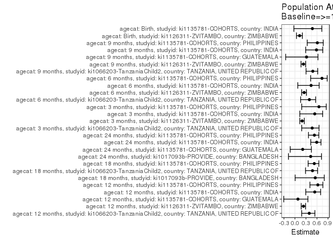

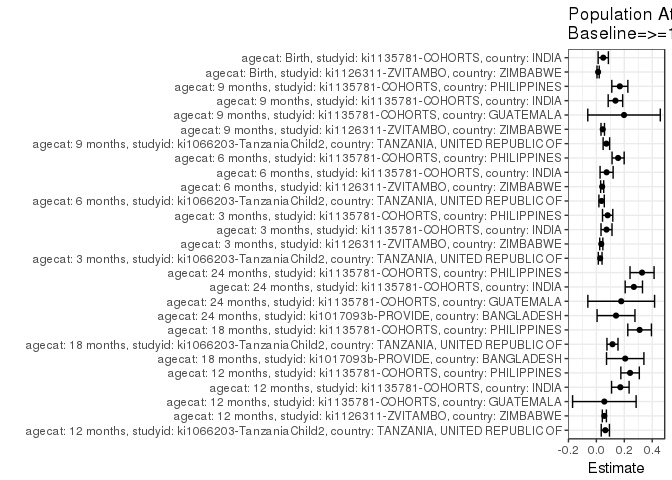

## Results Table

### Parameter: TSM

| agecat | studyid | country | intervention_level | baseline_level | estimate | ci_lower | ci_upper |
| --- | --- | --- | --- | --- | --- | --- | --- |
| Birth | ki1126311-ZVITAMBO | ZIMBABWE | >=160 | NA | 0.0865979 | 0.0786823 | 0.0945135 |
| Birth | ki1126311-ZVITAMBO | ZIMBABWE | <145 | NA | 0.2031250 | 0.1045521 | 0.3016979 |
| Birth | ki1126311-ZVITAMBO | ZIMBABWE | [145-150) | NA | 0.1205212 | 0.0841007 | 0.1569417 |
| Birth | ki1126311-ZVITAMBO | ZIMBABWE | [150-155) | NA | 0.1136935 | 0.0980994 | 0.1292875 |
| Birth | ki1126311-ZVITAMBO | ZIMBABWE | [155-160) | NA | 0.1075683 | 0.0962006 | 0.1189360 |
| Birth | ki1135781-COHORTS | INDIA | >=160 | NA | 0.0544218 | 0.0177403 | 0.0911033 |
| Birth | ki1135781-COHORTS | INDIA | <145 | NA | 0.1772152 | 0.1176578 | 0.2367726 |
| Birth | ki1135781-COHORTS | INDIA | [145-150) | NA | 0.1286920 | 0.0985381 | 0.1588458 |
| Birth | ki1135781-COHORTS | INDIA | [150-155) | NA | 0.1013072 | 0.0773949 | 0.1252194 |
| Birth | ki1135781-COHORTS | INDIA | [155-160) | NA | 0.0652742 | 0.0405294 | 0.0900189 |
| 3 months | ki1066203-TanzaniaChild2 | TANZANIA, UNITED REPUBLIC OF | >=160 | NA | 0.0307692 | 0.0174904 | 0.0440481 |
| 3 months | ki1066203-TanzaniaChild2 | TANZANIA, UNITED REPUBLIC OF | <145 | NA | 0.1470588 | 0.0279867 | 0.2661309 |
| 3 months | ki1066203-TanzaniaChild2 | TANZANIA, UNITED REPUBLIC OF | [145-150) | NA | 0.1085714 | 0.0624687 | 0.1546741 |
| 3 months | ki1066203-TanzaniaChild2 | TANZANIA, UNITED REPUBLIC OF | [150-155) | NA | 0.0720000 | 0.0517304 | 0.0922696 |
| 3 months | ki1066203-TanzaniaChild2 | TANZANIA, UNITED REPUBLIC OF | [155-160) | NA | 0.0543338 | 0.0383508 | 0.0703168 |
| 3 months | ki1126311-ZVITAMBO | ZIMBABWE | >=160 | NA | 0.1447402 | 0.1336531 | 0.1558274 |
| 3 months | ki1126311-ZVITAMBO | ZIMBABWE | <145 | NA | 0.2708333 | 0.1451088 | 0.3965578 |
| 3 months | ki1126311-ZVITAMBO | ZIMBABWE | [145-150) | NA | 0.3203125 | 0.2631518 | 0.3774732 |
| 3 months | ki1126311-ZVITAMBO | ZIMBABWE | [150-155) | NA | 0.2450230 | 0.2216951 | 0.2683508 |
| 3 months | ki1126311-ZVITAMBO | ZIMBABWE | [155-160) | NA | 0.1846355 | 0.1687465 | 0.2005245 |
| 3 months | ki1135781-COHORTS | INDIA | >=160 | NA | 0.0620690 | 0.0227858 | 0.1013521 |
| 3 months | ki1135781-COHORTS | INDIA | <145 | NA | 0.2574850 | 0.1911508 | 0.3238193 |
| 3 months | ki1135781-COHORTS | INDIA | [145-150) | NA | 0.1764706 | 0.1428102 | 0.2101310 |
| 3 months | ki1135781-COHORTS | INDIA | [150-155) | NA | 0.1233766 | 0.0973990 | 0.1493543 |
| 3 months | ki1135781-COHORTS | INDIA | [155-160) | NA | 0.0753769 | 0.0494335 | 0.1013203 |
| 3 months | ki1135781-COHORTS | PHILIPPINES | >=160 | NA | 0.0427350 | 0.0060796 | 0.0793905 |
| 3 months | ki1135781-COHORTS | PHILIPPINES | <145 | NA | 0.2434211 | 0.1951715 | 0.2916706 |
| 3 months | ki1135781-COHORTS | PHILIPPINES | [145-150) | NA | 0.1562156 | 0.1326098 | 0.1798215 |
| 3 months | ki1135781-COHORTS | PHILIPPINES | [150-155) | NA | 0.0928705 | 0.0754437 | 0.1102974 |
| 3 months | ki1135781-COHORTS | PHILIPPINES | [155-160) | NA | 0.0730689 | 0.0497587 | 0.0963791 |

[output cut: 105 more lines]

### Parameter: E(Y)

| agecat | studyid | country | intervention_level | baseline_level | estimate | ci_lower | ci_upper |
| --- | --- | --- | --- | --- | --- | --- | --- |
| Birth | ki1126311-ZVITAMBO | ZIMBABWE | NA | NA | 0.0991000 | 0.0988038 | 0.0993963 |
| Birth | ki1135781-COHORTS | INDIA | NA | NA | 0.1037204 | 0.1021281 | 0.1053127 |
| 3 months | ki1066203-TanzaniaChild2 | TANZANIA, UNITED REPUBLIC OF | NA | NA | 0.0580416 | 0.0570392 | 0.0590441 |
| 3 months | ki1126311-ZVITAMBO | ZIMBABWE | NA | NA | 0.1799228 | 0.1789195 | 0.1809261 |
| 3 months | ki1135781-COHORTS | INDIA | NA | NA | 0.1346894 | 0.1321338 | 0.1372450 |
| 3 months | ki1135781-COHORTS | PHILIPPINES | NA | NA | 0.1234783 | 0.1215108 | 0.1254457 |
| 6 months | ki1066203-TanzaniaChild2 | TANZANIA, UNITED REPUBLIC OF | NA | NA | 0.0951904 | 0.0934805 | 0.0969003 |
| 6 months | ki1126311-ZVITAMBO | ZIMBABWE | NA | NA | 0.1655908 | 0.1642937 | 0.1668879 |
| 6 months | ki1135781-COHORTS | INDIA | NA | NA | 0.1665750 | 0.1635902 | 0.1695599 |
| 6 months | ki1135781-COHORTS | PHILIPPINES | NA | NA | 0.2112260 | 0.2082452 | 0.2142068 |
| 9 months | ki1066203-TanzaniaChild2 | TANZANIA, UNITED REPUBLIC OF | NA | NA | 0.1473265 | 0.1444403 | 0.1502127 |
| 9 months | ki1126311-ZVITAMBO | ZIMBABWE | NA | NA | 0.1973224 | 0.1959745 | 0.1986702 |
| 9 months | ki1135781-COHORTS | GUATEMALA | NA | NA | 0.6266968 | 0.6188397 | 0.6345540 |
| 9 months | ki1135781-COHORTS | INDIA | NA | NA | 0.2324029 | 0.2281730 | 0.2366328 |
| 9 months | ki1135781-COHORTS | PHILIPPINES | NA | NA | 0.2750737 | 0.2712171 | 0.2789304 |
| 12 months | ki1066203-TanzaniaChild2 | TANZANIA, UNITED REPUBLIC OF | NA | NA | 0.1649123 | 0.1616226 | 0.1682019 |
| 12 months | ki1126311-ZVITAMBO | ZIMBABWE | NA | NA | 0.2468518 | 0.2451011 | 0.2486026 |
| 12 months | ki1135781-COHORTS | GUATEMALA | NA | NA | 0.7041420 | 0.6983689 | 0.7099151 |
| 12 months | ki1135781-COHORTS | INDIA | NA | NA | 0.3179153 | 0.3121351 | 0.3236956 |
| 12 months | ki1135781-COHORTS | PHILIPPINES | NA | NA | 0.3868472 | 0.3819001 | 0.3917943 |
| 18 months | ki1017093b-PROVIDE | BANGLADESH | NA | NA | 0.3731884 | 0.3640192 | 0.3823576 |
| 18 months | ki1066203-TanzaniaChild2 | TANZANIA, UNITED REPUBLIC OF | NA | NA | 0.2412008 | 0.2349059 | 0.2474957 |
| 18 months | ki1135781-COHORTS | PHILIPPINES | NA | NA | 0.5874799 | 0.5825105 | 0.5924494 |
| 24 months | ki1017093b-PROVIDE | BANGLADESH | NA | NA | 0.3281250 | 0.3197199 | 0.3365301 |
| 24 months | ki1135781-COHORTS | GUATEMALA | NA | NA | 0.8445378 | 0.8378193 | 0.8512564 |
| 24 months | ki1135781-COHORTS | INDIA | NA | NA | 0.4524464 | 0.4458841 | 0.4590087 |
| 24 months | ki1135781-COHORTS | PHILIPPINES | NA | NA | 0.6167689 | 0.6117312 | 0.6218066 |

### Parameter: RR

| agecat | studyid | country | intervention_level | baseline_level | estimate | ci_lower | ci_upper |
| --- | --- | --- | --- | --- | --- | --- | --- |
| Birth | ki1126311-ZVITAMBO | ZIMBABWE | >=160 | >=160 | 1.0000000 | 1.0000000 | 1.000000 |
| Birth | ki1126311-ZVITAMBO | ZIMBABWE | <145 | >=160 | 2.3456101 | 1.4315106 | 3.843413 |
| Birth | ki1126311-ZVITAMBO | ZIMBABWE | [145-150) | >=160 | 1.3917326 | 1.0149467 | 1.908395 |
| Birth | ki1126311-ZVITAMBO | ZIMBABWE | [150-155) | >=160 | 1.3128888 | 1.1133838 | 1.548143 |
| Birth | ki1126311-ZVITAMBO | ZIMBABWE | [155-160) | >=160 | 1.2421580 | 1.0801768 | 1.428430 |
| Birth | ki1135781-COHORTS | INDIA | >=160 | >=160 | 1.0000000 | 1.0000000 | 1.000000 |
| Birth | ki1135781-COHORTS | INDIA | <145 | >=160 | 3.2563291 | 1.5333263 | 6.915475 |
| Birth | ki1135781-COHORTS | INDIA | [145-150) | >=160 | 2.3647152 | 1.1584349 | 4.827097 |
| Birth | ki1135781-COHORTS | INDIA | [150-155) | >=160 | 1.8615196 | 0.9114091 | 3.802085 |
| Birth | ki1135781-COHORTS | INDIA | [155-160) | >=160 | 1.1994125 | 0.5535060 | 2.599051 |
| 3 months | ki1066203-TanzaniaChild2 | TANZANIA, UNITED REPUBLIC OF | >=160 | >=160 | 1.0000000 | 1.0000000 | 1.000000 |
| 3 months | ki1066203-TanzaniaChild2 | TANZANIA, UNITED REPUBLIC OF | <145 | >=160 | 4.7794118 | 1.9094153 | 11.963231 |
| 3 months | ki1066203-TanzaniaChild2 | TANZANIA, UNITED REPUBLIC OF | [145-150) | >=160 | 3.5285714 | 1.9260171 | 6.464541 |
| 3 months | ki1066203-TanzaniaChild2 | TANZANIA, UNITED REPUBLIC OF | [150-155) | >=160 | 2.3400000 | 1.3977782 | 3.917360 |
| 3 months | ki1066203-TanzaniaChild2 | TANZANIA, UNITED REPUBLIC OF | [155-160) | >=160 | 1.7658473 | 1.0474404 | 2.976987 |
| 3 months | ki1126311-ZVITAMBO | ZIMBABWE | >=160 | >=160 | 1.0000000 | 1.0000000 | 1.000000 |
| 3 months | ki1126311-ZVITAMBO | ZIMBABWE | <145 | >=160 | 1.8711682 | 1.1689102 | 2.995329 |
| 3 months | ki1126311-ZVITAMBO | ZIMBABWE | [145-150) | >=160 | 2.2130162 | 1.8224064 | 2.687348 |
| 3 months | ki1126311-ZVITAMBO | ZIMBABWE | [150-155) | >=160 | 1.6928462 | 1.4981258 | 1.912875 |
| 3 months | ki1126311-ZVITAMBO | ZIMBABWE | [155-160) | >=160 | 1.2756337 | 1.1368183 | 1.431400 |
| 3 months | ki1135781-COHORTS | INDIA | >=160 | >=160 | 1.0000000 | 1.0000000 | 1.000000 |
| 3 months | ki1135781-COHORTS | INDIA | <145 | >=160 | 4.1483699 | 2.0946690 | 8.215605 |
| 3 months | ki1135781-COHORTS | INDIA | [145-150) | >=160 | 2.8431373 | 1.4679907 | 5.506458 |
| 3 months | ki1135781-COHORTS | INDIA | [150-155) | >=160 | 1.9877345 | 1.0201961 | 3.872872 |
| 3 months | ki1135781-COHORTS | INDIA | [155-160) | >=160 | 1.2144054 | 0.5908610 | 2.495985 |
| 3 months | ki1135781-COHORTS | PHILIPPINES | >=160 | >=160 | 1.0000000 | 1.0000000 | 1.000000 |
| 3 months | ki1135781-COHORTS | PHILIPPINES | <145 | >=160 | 5.6960523 | 2.3618153 | 13.737319 |
| 3 months | ki1135781-COHORTS | PHILIPPINES | [145-150) | >=160 | 3.6554453 | 1.5300046 | 8.733491 |
| 3 months | ki1135781-COHORTS | PHILIPPINES | [150-155) | >=160 | 2.1731706 | 0.9031771 | 5.228953 |
| 3 months | ki1135781-COHORTS | PHILIPPINES | [155-160) | >=160 | 1.7098120 | 0.6847104 | 4.269626 |

[output cut: 105 more lines]

### Parameter: PAR

| agecat | studyid | country | intervention_level | baseline_level | estimate | ci_lower | ci_upper |
| --- | --- | --- | --- | --- | --- | --- | --- |
| Birth | ki1126311-ZVITAMBO | ZIMBABWE | >=160 | NA | 0.0125021 | 0.0045809 | 0.0204232 |
| Birth | ki1135781-COHORTS | INDIA | >=160 | NA | 0.0492986 | 0.0125826 | 0.0860147 |
| 3 months | ki1066203-TanzaniaChild2 | TANZANIA, UNITED REPUBLIC OF | >=160 | NA | 0.0272724 | 0.0139558 | 0.0405890 |
| 3 months | ki1126311-ZVITAMBO | ZIMBABWE | >=160 | NA | 0.0351825 | 0.0240501 | 0.0463150 |
| 3 months | ki1135781-COHORTS | INDIA | >=160 | NA | 0.0726204 | 0.0332542 | 0.1119866 |
| 3 months | ki1135781-COHORTS | PHILIPPINES | >=160 | NA | 0.0807432 | 0.0440350 | 0.1174515 |
| 6 months | ki1066203-TanzaniaChild2 | TANZANIA, UNITED REPUBLIC OF | >=160 | NA | 0.0373970 | 0.0181760 | 0.0566180 |
| 6 months | ki1126311-ZVITAMBO | ZIMBABWE | >=160 | NA | 0.0415094 | 0.0305684 | 0.0524504 |
| 6 months | ki1135781-COHORTS | INDIA | >=160 | NA | 0.0732417 | 0.0265807 | 0.1199027 |
| 6 months | ki1135781-COHORTS | PHILIPPINES | >=160 | NA | 0.1556704 | 0.1123593 | 0.1989816 |
| 9 months | ki1066203-TanzaniaChild2 | TANZANIA, UNITED REPUBLIC OF | >=160 | NA | 0.0716293 | 0.0483045 | 0.0949541 |
| 9 months | ki1126311-ZVITAMBO | ZIMBABWE | >=160 | NA | 0.0456215 | 0.0332384 | 0.0580046 |
| 9 months | ki1135781-COHORTS | GUATEMALA | >=160 | NA | 0.1981254 | -0.0615121 | 0.4577629 |
| 9 months | ki1135781-COHORTS | INDIA | >=160 | NA | 0.1364029 | 0.0845712 | 0.1882346 |
| 9 months | ki1135781-COHORTS | PHILIPPINES | >=160 | NA | 0.1679309 | 0.1105095 | 0.2253523 |
| 12 months | ki1066203-TanzaniaChild2 | TANZANIA, UNITED REPUBLIC OF | >=160 | NA | 0.0641752 | 0.0347397 | 0.0936106 |
| 12 months | ki1126311-ZVITAMBO | ZIMBABWE | >=160 | NA | 0.0571596 | 0.0425160 | 0.0718032 |
| 12 months | ki1135781-COHORTS | GUATEMALA | >=160 | NA | 0.0570832 | -0.1703822 | 0.2845486 |
| 12 months | ki1135781-COHORTS | INDIA | >=160 | NA | 0.1715738 | 0.1088239 | 0.2343238 |
| 12 months | ki1135781-COHORTS | PHILIPPINES | >=160 | NA | 0.2413926 | 0.1753100 | 0.3074753 |
| 18 months | ki1017093b-PROVIDE | BANGLADESH | >=160 | NA | 0.2065217 | 0.0727276 | 0.3403159 |
| 18 months | ki1066203-TanzaniaChild2 | TANZANIA, UNITED REPUBLIC OF | >=160 | NA | 0.1153015 | 0.0757810 | 0.1548221 |
| 18 months | ki1135781-COHORTS | PHILIPPINES | >=160 | NA | 0.3097022 | 0.2250657 | 0.3943386 |
| 24 months | ki1017093b-PROVIDE | BANGLADESH | >=160 | NA | 0.1406250 | 0.0050129 | 0.2762371 |
| 24 months | ki1135781-COHORTS | GUATEMALA | >=160 | NA | 0.1778711 | -0.0610335 | 0.4167758 |
| 24 months | ki1135781-COHORTS | INDIA | >=160 | NA | 0.2682359 | 0.2062434 | 0.3302283 |
| 24 months | ki1135781-COHORTS | PHILIPPINES | >=160 | NA | 0.3270493 | 0.2409314 | 0.4131672 |

### Parameter: PAF

| agecat | studyid | country | intervention_level | baseline_level | estimate | ci_lower | ci_upper |
| --- | --- | --- | --- | --- | --- | --- | --- |
| Birth | ki1126311-ZVITAMBO | ZIMBABWE | >=160 | NA | 0.1261563 | 0.0424702 | 0.2025284 |
| Birth | ki1135781-COHORTS | INDIA | >=160 | NA | 0.4753032 | -0.0296948 | 0.7326327 |
| 3 months | ki1066203-TanzaniaChild2 | TANZANIA, UNITED REPUBLIC OF | >=160 | NA | 0.4698767 | 0.1835082 | 0.6558070 |
| 3 months | ki1126311-ZVITAMBO | ZIMBABWE | >=160 | NA | 0.1955424 | 0.1313230 | 0.2550142 |
| 3 months | ki1135781-COHORTS | INDIA | >=160 | NA | 0.5391696 | 0.1319846 | 0.7553446 |
| 3 months | ki1135781-COHORTS | PHILIPPINES | >=160 | NA | 0.6539063 | 0.1838521 | 0.8532364 |
| 6 months | ki1066203-TanzaniaChild2 | TANZANIA, UNITED REPUBLIC OF | >=160 | NA | 0.3928657 | 0.1540166 | 0.5642798 |
| 6 months | ki1126311-ZVITAMBO | ZIMBABWE | >=160 | NA | 0.2506745 | 0.1818239 | 0.3137313 |
| 6 months | ki1135781-COHORTS | INDIA | >=160 | NA | 0.4396919 | 0.0769123 | 0.6598968 |
| 6 months | ki1135781-COHORTS | PHILIPPINES | >=160 | NA | 0.7369852 | 0.4274559 | 0.8791765 |
| 9 months | ki1066203-TanzaniaChild2 | TANZANIA, UNITED REPUBLIC OF | >=160 | NA | 0.4861942 | 0.3019877 | 0.6217884 |
| 9 months | ki1126311-ZVITAMBO | ZIMBABWE | >=160 | NA | 0.2312028 | 0.1659799 | 0.2913251 |
| 9 months | ki1135781-COHORTS | GUATEMALA | >=160 | NA | 0.3161423 | -0.2531592 | 0.6268141 |
| 9 months | ki1135781-COHORTS | INDIA | >=160 | NA | 0.5869243 | 0.2922778 | 0.7589004 |
| 9 months | ki1135781-COHORTS | PHILIPPINES | >=160 | NA | 0.6104941 | 0.3350010 | 0.7718570 |
| 12 months | ki1066203-TanzaniaChild2 | TANZANIA, UNITED REPUBLIC OF | >=160 | NA | 0.3891474 | 0.1827784 | 0.5434030 |
| 12 months | ki1126311-ZVITAMBO | ZIMBABWE | >=160 | NA | 0.2315544 | 0.1700709 | 0.2884830 |
| 12 months | ki1135781-COHORTS | GUATEMALA | >=160 | NA | 0.0810677 | -0.3060103 | 0.3534228 |
| 12 months | ki1135781-COHORTS | INDIA | >=160 | NA | 0.5396841 | 0.2942451 | 0.6997673 |
| 12 months | ki1135781-COHORTS | PHILIPPINES | >=160 | NA | 0.6240000 | 0.4084106 | 0.7610235 |
| 18 months | ki1017093b-PROVIDE | BANGLADESH | >=160 | NA | 0.5533981 | 0.0048214 | 0.7995804 |
| 18 months | ki1066203-TanzaniaChild2 | TANZANIA, UNITED REPUBLIC OF | >=160 | NA | 0.4780313 | 0.2876259 | 0.6175446 |
| 18 months | ki1135781-COHORTS | PHILIPPINES | >=160 | NA | 0.5271706 | 0.3590075 | 0.6512165 |
| 24 months | ki1017093b-PROVIDE | BANGLADESH | >=160 | NA | 0.4285714 | -0.1766985 | 0.7225027 |
| 24 months | ki1135781-COHORTS | GUATEMALA | >=160 | NA | 0.2106136 | -0.1295330 | 0.4483287 |
| 24 months | ki1135781-COHORTS | INDIA | >=160 | NA | 0.5928567 | 0.4308641 | 0.7087415 |
| 24 months | ki1135781-COHORTS | PHILIPPINES | >=160 | NA | 0.5302623 | 0.3679153 | 0.6509115 |